# Lab 7

```python
import pandas as pd

ha = pd.read_csv("https://www.dropbox.com/s/aohbr6yb9ifmc8w/heart_attack.csv?dl=1")

df = ha
df.describe()
```

|  | age | sex | cp | trtbps | chol | restecg | thalach | output |
| --- | --- | --- | --- | --- | --- | --- | --- | --- |
| count | 273.000000 | 273.000000 | 273.000000 | 273.000000 | 273.000000 | 273.000000 | 273.000000 | 273.000000 |
| mean | 54.347985 | 0.673993 | 0.974359 | 132.098901 | 246.860806 | 0.538462 | 149.446886 | 0.534799 |
| std | 9.163134 | 0.469611 | 1.030456 | 17.700358 | 52.569726 | 0.528059 | 23.240707 | 0.499704 |
| min | 29.000000 | 0.000000 | 0.000000 | 94.000000 | 126.000000 | 0.000000 | 71.000000 | 0.000000 |
| 25% | 47.000000 | 0.000000 | 0.000000 | 120.000000 | 211.000000 | 0.000000 | 133.000000 | 0.000000 |
| 50% | 56.000000 | 1.000000 | 1.000000 | 130.000000 | 240.000000 | 1.000000 | 152.000000 | 1.000000 |
| 75% | 61.000000 | 1.000000 | 2.000000 | 140.000000 | 275.000000 | 1.000000 | 166.000000 | 1.000000 |
| max | 77.000000 | 1.000000 | 3.000000 | 200.000000 | 564.000000 | 2.000000 | 202.000000 | 1.000000 |

```python
df_clean = df.dropna()
df_clean.head
```

```
<bound method NDFrame.head of      age  sex  cp  trtbps  chol  restecg  thalach  output
0     63    1   3     145   233        0      150       1
1     37    1   2     130   250        1      187       1
2     56    1   1     120   236        1      178       1
3     57    0   0     120   354        1      163       1
4     57    1   0     140   192        1      148       1
..   ...  ...  ..     ...   ...      ...      ...     ...
268   59    1   0     164   176        0       90       0
269   57    0   0     140   241        1      123       0
270   45    1   3     110   264        1      132       0
271   68    1   0     144   193        1      141       0
272   57    0   1     130   236        0      174       0

[273 rows x 8 columns]>
```

# Part 1

## Knn

```python
from sklearn.pipeline import Pipeline
from sklearn.preprocessing import StandardScaler, OneHotEncoder
from sklearn.compose import ColumnTransformer
from sklearn.neighbors import KNeighborsClassifier

X = df_clean.drop(columns=['output'])
y = df_clean['output']

ct = ColumnTransformer(
  [
    ("dummify", OneHotEncoder(sparse_output = False), ["cp", "restecg", "sex"]),
    ("standardize", StandardScaler(), ["age", "chol", "trtbps", "thalach"])
  ],
  remainder = "passthrough"
)

knn_pipeline = Pipeline(
  [("preprocessing", ct),
  ("knn", KNeighborsClassifier())]
)

knn_pipeline

knn_pipeline_fitted = knn_pipeline.fit(X, y)

y_preds_knn = knn_pipeline_fitted.predict(X)
```

```python
from sklearn.model_selection import GridSearchCV

param_grid_knn = {
    'knn__n_neighbors': [3, 5, 7, 9, 11, 13, 15, 17, 19, 21, 23, 25, 27, 29],
    'knn__weights': ['uniform', 'distance'],
    'knn__metric': ['euclidean', 'manhattan']
}

knn_grid_search = GridSearchCV(knn_pipeline, param_grid_knn, cv=5, scoring='roc_auc')

knn_grid_search_fitted = knn_grid_search.fit(X, y)
knn_df_cv_results_ = pd.DataFrame(knn_grid_search_fitted.cv_results_)

knn_df_cv_results_
```

[output not shown]

```python
from sklearn.model_selection import cross_val_score

knn_scores = cross_val_score(knn_pipeline, X, y, cv = 5, scoring = 'roc_auc')

knn_scores
```

```
array([0.75066667, 0.79376658, 0.80371353, 0.87241379, 0.64137931])
```

```python
import numpy as np

roc_auc_knn = np.mean(knn_scores)
print(f"Cross Validated ROC AUC {roc_auc_knn}")
```

```
Cross Validated ROC AUC 0.7723879752431477
```

```python
knn_pipeline.set_params(knn__n_neighbors=23, knn__weights='uniform', knn__metric='manhattan')
knn_pipeline_fitted = knn_pipeline.fit(X, y)
y_preds_knn = knn_pipeline_fitted.predict(X)
```

```python
from sklearn.metrics import confusion_matrix

knn_cm = confusion_matrix(y, y_preds_knn)
print(knn_cm)
```

```
[[104  23]
 [ 36 110]]
```

## Logistic

```python
from sklearn.linear_model import LogisticRegression
from sklearn.pipeline import Pipeline
from sklearn.preprocessing import StandardScaler, OneHotEncoder
from sklearn.compose import ColumnTransformer

lr_pipeline = Pipeline(
  [("preprocessing", ct),
  ("logistic_regression", LogisticRegression())]
)

lr_pipeline

lr_pipeline_fitted = lr_pipeline.fit(X, y)

y_preds_log = lr_pipeline_fitted.predict(X)
```

```python
from sklearn.model_selection import GridSearchCV

param_grid_log = {
    'logistic_regression__C': [0.01, 0.1, 1, 10, 100]
}

log_grid_search = GridSearchCV(lr_pipeline, param_grid_log, cv=5, scoring='roc_auc')

log_grid_search_fitted = log_grid_search.fit(X, y)
log_df_cv_results_ = pd.DataFrame(log_grid_search_fitted.cv_results_)

log_df_cv_results_
```

|  | mean_fit_time | std_fit_time | mean_score_time | std_score_time | param_logistic_regression__C | params | split0_test_score | split1_test_score | split2_test_score | split3_test_score | split4_test_score | mean_test_score | std_test_score | rank_test_score |
| --- | --- | --- | --- | --- | --- | --- | --- | --- | --- | --- | --- | --- | --- | --- |
| 0 | 0.006369 | 0.003580 | 0.003412 | 0.000780 | 0.01 | {'logistic_regression__C': 0.01} | 0.790667 | 0.895225 | 0.885942 | 0.877241 | 0.714483 | 0.832712 | 0.069957 | 5 |
| 1 | 0.004497 | 0.001036 | 0.002461 | 0.000393 | 0.10 | {'logistic_regression__C': 0.1} | 0.818667 | 0.900531 | 0.904509 | 0.917241 | 0.762759 | 0.860741 | 0.060103 | 4 |
| 2 | 0.006190 | 0.002038 | 0.004341 | 0.002473 | 1.00 | {'logistic_regression__C': 1} | 0.826667 | 0.884615 | 0.908488 | 0.921379 | 0.780690 | 0.864368 | 0.052972 | 1 |
| 3 | 0.007462 | 0.003794 | 0.004067 | 0.001732 | 10.00 | {'logistic_regression__C': 10} | 0.829333 | 0.876658 | 0.911141 | 0.915862 | 0.782069 | 0.863013 | 0.050954 | 2 |
| 4 | 0.004514 | 0.001021 | 0.002766 | 0.000395 | 100.00 | {'logistic_regression__C': 100} | 0.830667 | 0.876658 | 0.911141 | 0.917241 | 0.779310 | 0.863003 | 0.051953 | 3 |

```python
from sklearn.model_selection import cross_val_score

log_scores = cross_val_score(lr_pipeline, X, y, cv = 5, scoring = 'roc_auc')

log_scores
```

```
array([0.82666667, 0.88461538, 0.90848806, 0.92137931, 0.78068966])
```

```python
import numpy as np

roc_auc_log = np.mean(log_scores)
print(f"Cross Validated ROC AUC {roc_auc_log}")
```

```
Cross Validated ROC AUC 0.864367816091954
```

```python
lr_pipeline.set_params(logistic_regression__C=1)
lr_pipeline_fitted = lr_pipeline.fit(X, y)
y_preds_log = lr_pipeline_fitted.predict(X)
```

```python
from sklearn.metrics import confusion_matrix

cm = confusion_matrix(y, y_preds_log)
print(cm)
```

```
[[ 96  31]
 [ 24 122]]
```

```python
model_lr = lr_pipeline.named_steps["logistic_regression"]
feature_names = lr_pipeline[:-1].get_feature_names_out()
coefficients = model_lr.coef_
coefficients = coefficients.squeeze()
lr_coef_df = pd.DataFrame({
    'predictor': feature_names,
    'coefficient': coefficients
})
lr_coef_df = lr_coef_df.sort_values(by='coefficient', ascending=False)

lr_coef_df
```

|  | predictor | coefficient |
| --- | --- | --- |
| 7 | dummify__sex_0 | 0.995994 |
| 12 | standardize__thalach | 0.761459 |
| 1 | dummify__cp_1 | 0.611635 |
| 2 | dummify__cp_2 | 0.483018 |
| 3 | dummify__cp_3 | 0.310153 |
| 5 | dummify__restecg_1 | 0.299090 |
| 4 | dummify__restecg_0 | -0.033291 |
| 9 | standardize__age | -0.232172 |
| 6 | dummify__restecg_2 | -0.266461 |
| 10 | standardize__chol | -0.273970 |
| 11 | standardize__trtbps | -0.322502 |
| 8 | dummify__sex_1 | -0.996657 |
| 0 | dummify__cp_0 | -1.405470 |

## Lasso

```python
from sklearn.linear_model import Lasso

lasso_clf = LogisticRegression(
    penalty = "l1",
    solver = "saga",
    max_iter = 10000
)


lasso_pipeline = Pipeline([
    ("preprocess", ct),
    ("lasso_clf", lasso_clf)
])


lasso_pipeline

lasso_pipeline_fitted = lasso_pipeline.fit(X, y)

y_preds_lasso = lasso_pipeline_fitted.predict(X)
```

```python
from sklearn.model_selection import GridSearchCV

param_grid = {
    "lasso_clf__C": [0.001, 0.01, 0.1, 1, 10]
}

lasso_grid_search = GridSearchCV(lasso_pipeline, param_grid, cv=5, scoring='roc_auc')

lasso_grid_search_fitted = lasso_grid_search.fit(X, y)
lasso_df_cv_results_ = pd.DataFrame(lasso_grid_search_fitted.cv_results_)

lasso_df_cv_results_
```

|  | mean_fit_time | std_fit_time | mean_score_time | std_score_time | param_lasso_clf__C | params | split0_test_score | split1_test_score | split2_test_score | split3_test_score | split4_test_score | mean_test_score | std_test_score | rank_test_score |
| --- | --- | --- | --- | --- | --- | --- | --- | --- | --- | --- | --- | --- | --- | --- |
| 0 | 0.005008 | 0.002497 | 0.003520 | 0.001755 | 0.001 | {'lasso_clf__C': 0.001} | 0.500000 | 0.500000 | 0.500000 | 0.500000 | 0.500000 | 0.500000 | 0.000000 | 4 |
| 1 | 0.003192 | 0.000324 | 0.002282 | 0.000160 | 0.010 | {'lasso_clf__C': 0.01} | 0.500000 | 0.500000 | 0.500000 | 0.500000 | 0.500000 | 0.500000 | 0.000000 | 4 |
| 2 | 0.004263 | 0.000828 | 0.003337 | 0.001319 | 0.100 | {'lasso_clf__C': 0.1} | 0.825333 | 0.905836 | 0.859416 | 0.859310 | 0.740690 | 0.838117 | 0.055035 | 3 |
| 3 | 0.006243 | 0.001724 | 0.003896 | 0.001766 | 1.000 | {'lasso_clf__C': 1} | 0.841333 | 0.885942 | 0.908488 | 0.924138 | 0.782069 | 0.868394 | 0.051395 | 1 |
| 4 | 0.011269 | 0.001757 | 0.002599 | 0.000166 | 10.000 | {'lasso_clf__C': 10} | 0.832000 | 0.876658 | 0.909814 | 0.915862 | 0.782069 | 0.863281 | 0.050365 | 2 |

```python
from sklearn.model_selection import cross_val_score

lasso_scores = cross_val_score(lasso_pipeline, X, y, cv = 5, scoring = 'roc_auc')

lasso_scores
```

```
array([0.84133333, 0.88594164, 0.90848806, 0.92413793, 0.78206897])
```

```python
import numpy as np

roc_auc_lasso = np.mean(lasso_scores)
print(f"Cross Validated ROC AUC {roc_auc_lasso}")
```

```
Cross Validated ROC AUC 0.8683939876215738
```

```python
lasso_pipeline.set_params(lasso_clf__C=1)
lasso_pipeline_fitted = lasso_pipeline.fit(X, y)
y_preds_lasso = lasso_pipeline_fitted.predict(X)
```

```python
from sklearn.metrics import confusion_matrix

lasso_cm = confusion_matrix(y, y_preds_lasso)
print(lasso_cm)
```

```
[[ 95  32]
 [ 24 122]]
```

```python
model_lasso = lasso_pipeline.named_steps["lasso_clf"]
feature_names = lasso_pipeline[:-1].get_feature_names_out()
coefficients = model_lasso.coef_
coefficients = coefficients.squeeze()
lasso_coef_df = pd.DataFrame({
    'predictor': feature_names,
    'coefficient': coefficients
})
lasso_coef_df = lasso_coef_df.sort_values(by='coefficient', ascending=False)

lasso_coef_df
```

|  | predictor | coefficient |
| --- | --- | --- |
| 7 | dummify__sex_0 | 1.421483 |
| 12 | standardize__thalach | 0.757687 |
| 5 | dummify__restecg_1 | 0.286598 |
| 1 | dummify__cp_1 | 0.053739 |
| 2 | dummify__cp_2 | 0.000000 |
| 3 | dummify__cp_3 | 0.000000 |
| 4 | dummify__restecg_0 | 0.000000 |
| 6 | dummify__restecg_2 | 0.000000 |
| 9 | standardize__age | -0.222197 |
| 10 | standardize__chol | -0.254962 |
| 11 | standardize__trtbps | -0.324306 |
| 8 | dummify__sex_1 | -0.550489 |
| 0 | dummify__cp_0 | -1.921078 |

## Ridge

```python
from sklearn.linear_model import RidgeClassifier

ridge_pipeline = Pipeline([
    ("preprocess", ct),
    ("ridge_clf", RidgeClassifier())
])


ridge_pipeline

ridge_pipeline_fitted = ridge_pipeline.fit(X, y)

y_preds_ridge = ridge_pipeline_fitted.predict(X)
```

```python
from sklearn.model_selection import GridSearchCV

param_grid = {
    "ridge_clf__alpha": [0.001, 0.01, 0.1, 1, 10]
}

ridge_grid_search = GridSearchCV(ridge_pipeline, param_grid, cv=5, scoring='roc_auc')

ridge_grid_search_fitted = ridge_grid_search.fit(X, y)
ridge_df_cv_results_ = pd.DataFrame(ridge_grid_search_fitted.cv_results_)

ridge_df_cv_results_
```

|  | mean_fit_time | std_fit_time | mean_score_time | std_score_time | param_ridge_clf__alpha | params | split0_test_score | split1_test_score | split2_test_score | split3_test_score | split4_test_score | mean_test_score | std_test_score | rank_test_score |
| --- | --- | --- | --- | --- | --- | --- | --- | --- | --- | --- | --- | --- | --- | --- |
| 0 | 0.004228 | 0.000264 | 0.002585 | 0.000189 | 0.001 | {'ridge_clf__alpha': 0.001} | 0.830667 | 0.866048 | 0.889920 | 0.915862 | 0.777931 | 0.856086 | 0.048107 | 3 |
| 1 | 0.003537 | 0.000173 | 0.002580 | 0.000164 | 0.010 | {'ridge_clf__alpha': 0.01} | 0.830667 | 0.866048 | 0.889920 | 0.915862 | 0.777931 | 0.856086 | 0.048107 | 3 |
| 2 | 0.003629 | 0.000107 | 0.002474 | 0.000129 | 0.100 | {'ridge_clf__alpha': 0.1} | 0.830667 | 0.866048 | 0.889920 | 0.915862 | 0.777931 | 0.856086 | 0.048107 | 3 |
| 3 | 0.003564 | 0.000196 | 0.002423 | 0.000132 | 1.000 | {'ridge_clf__alpha': 1} | 0.830667 | 0.867374 | 0.888594 | 0.915862 | 0.783448 | 0.857189 | 0.046203 | 2 |
| 4 | 0.003521 | 0.000171 | 0.002417 | 0.000182 | 10.000 | {'ridge_clf__alpha': 10} | 0.829333 | 0.883289 | 0.896552 | 0.921379 | 0.779310 | 0.861973 | 0.051142 | 1 |

```python
from sklearn.model_selection import cross_val_score

ridge_scores = cross_val_score(ridge_pipeline, X, y, cv=5, scoring='roc_auc')

ridge_scores
```

```
array([0.83066667, 0.86737401, 0.88859416, 0.91586207, 0.78344828])
```

```python
import numpy as np

roc_auc_ridge = np.mean(ridge_scores)
print(f"Cross Validated ROC AUC {roc_auc_ridge}")
```

```
Cross Validated ROC AUC 0.8571890362511052
```

```python
ridge_pipeline.set_params(ridge_clf__alpha=10)
ridge_pipeline_fitted = ridge_pipeline.fit(X, y)
y_preds_ridge = ridge_pipeline_fitted.predict(X)
```

```python
from sklearn.metrics import confusion_matrix

cm = confusion_matrix(y, y_preds_ridge)
print(cm)
```

```
[[ 96  31]
 [ 28 118]]
```

```python
model_ridge = ridge_pipeline.named_steps["ridge_clf"]
feature_names = ridge_pipeline[:-1].get_feature_names_out()
coefficients = model_ridge.coef_
coefficients = coefficients.squeeze()
ridge_coef_df = pd.DataFrame({
    'predictor': feature_names,
    'coefficient': coefficients
})
ridge_coef_df = ridge_coef_df.sort_values(by='coefficient', ascending=False)

ridge_coef_df
```

|  | predictor | coefficient |
| --- | --- | --- |
| 7 | dummify__sex_0 | 0.282621 |
| 12 | standardize__thalach | 0.225764 |
| 1 | dummify__cp_1 | 0.200214 |
| 2 | dummify__cp_2 | 0.186820 |
| 3 | dummify__cp_3 | 0.103687 |
| 5 | dummify__restecg_1 | 0.089121 |
| 4 | dummify__restecg_0 | -0.018600 |
| 9 | standardize__age | -0.066318 |
| 10 | standardize__chol | -0.067626 |
| 6 | dummify__restecg_2 | -0.070521 |
| 11 | standardize__trtbps | -0.089080 |
| 8 | dummify__sex_1 | -0.282621 |
| 0 | dummify__cp_0 | -0.490722 |

## Elastic

```python
from sklearn.linear_model import LogisticRegression

elastic_clf = LogisticRegression(
    penalty='elasticnet',
    solver='saga',
    l1_ratio=0.5,
    max_iter=10000
)


elastic_pipeline = Pipeline([
    ("preprocess", ct),
    ("elastic_clf", elastic_clf)
])


elastic_pipeline

elastic_pipeline_fitted = elastic_pipeline.fit(X, y)

y_preds_elastic = elastic_pipeline_fitted.predict(X)
```

```python
from sklearn.model_selection import GridSearchCV

param_grid = {
    "elastic_clf__C": [0.001, 0.01, 0.1, 1, 10],
    "elastic_clf__l1_ratio": [0.2, 0.5, 0.8]
}

elastic_grid_search = GridSearchCV(elastic_pipeline, param_grid, cv=5, scoring='roc_auc')

elastic_grid_search_fitted = elastic_grid_search.fit(X, y)
elastic_df_cv_results_ = pd.DataFrame(elastic_grid_search_fitted.cv_results_)

elastic_df_cv_results_
```

[output not shown]

```python
from sklearn.model_selection import cross_val_score

elastic_scores = cross_val_score(elastic_pipeline, X, y, cv=5, scoring='roc_auc')

elastic_scores
```

```
array([0.832     , 0.8872679 , 0.9071618 , 0.92137931, 0.78068966])
```

```python
import numpy as np

roc_auc_elastic = np.mean(elastic_scores)
print(f"Cross Validated ROC AUC {roc_auc_elastic}")
```

```
Cross Validated ROC AUC 0.8656997347480108
```

```python
elastic_pipeline.set_params(elastic_clf__C=1, elastic_clf__l1_ratio=0.8)
elastic_pipeline_fitted = elastic_pipeline.fit(X, y)
y_preds_elastic = elastic_pipeline_fitted.predict(X)
```

```python
from sklearn.metrics import confusion_matrix

cm = confusion_matrix(y, y_preds_elastic)
print(cm)
```

```
[[ 94  33]
 [ 24 122]]
```

```python
model_elastic = elastic_pipeline.named_steps["elastic_clf"]
feature_names = elastic_pipeline[:-1].get_feature_names_out()
coefficients = model_elastic.coef_
coefficients = coefficients.squeeze()
elastic_coef_df = pd.DataFrame({
    'predictor': feature_names,
    'coefficient': coefficients
})
elastic_coef_df = elastic_coef_df.sort_values(by='coefficient', ascending=False)

elastic_coef_df
```

|  | predictor | coefficient |
| --- | --- | --- |
| 7 | dummify__sex_0 | 1.018781 |
| 12 | standardize__thalach | 0.758729 |
| 5 | dummify__restecg_1 | 0.297849 |
| 1 | dummify__cp_1 | 0.107414 |
| 2 | dummify__cp_2 | 0.000000 |
| 3 | dummify__cp_3 | 0.000000 |
| 4 | dummify__restecg_0 | 0.000000 |
| 6 | dummify__restecg_2 | 0.000000 |
| 9 | standardize__age | -0.224246 |
| 10 | standardize__chol | -0.259053 |
| 11 | standardize__trtbps | -0.323705 |
| 8 | dummify__sex_1 | -0.956011 |
| 0 | dummify__cp_0 | -1.888761 |

## Tree

```python
from sklearn.tree import DecisionTreeClassifier

tree_pipeline = Pipeline(
  [("preprocessing", ct),
  ("tree", DecisionTreeClassifier())]
)

tree_pipeline

tree_pipeline_fitted = tree_pipeline.fit(X, y)

y_preds_tree = tree_pipeline_fitted.predict(X)
```

```python
from sklearn.model_selection import GridSearchCV

param_grid_tree = {
    "tree__max_depth": [1, 3, 7, 9],
    'tree__min_samples_leaf': [1, 2, 4, 6, 8],
    'tree__criterion': ['gini', 'entropy', 'log_loss']
    }

tree_grid_search = GridSearchCV(tree_pipeline, param_grid_tree, cv=5, scoring='roc_auc')

tree_grid_search_fitted = tree_grid_search.fit(X, y)
tree_df_cv_results_ = pd.DataFrame(tree_grid_search_fitted.cv_results_)

tree_df_cv_results_
```

[output not shown]

```python
from sklearn.model_selection import cross_val_score

tree_scores = cross_val_score(tree_pipeline, X, y, cv = 5, scoring = 'roc_auc')

tree_scores
```

```
array([0.67333333, 0.74469496, 0.63925729, 0.73655172, 0.68206897])
```

```python
import numpy as np

roc_auc_tree = np.mean(tree_scores)
print(f"Cross Validated ROC AUC {roc_auc_tree}")
```

```
Cross Validated ROC AUC 0.695181255526083
```

```python
tree_pipeline.set_params(tree__max_depth=3, tree__min_samples_leaf=8, tree__criterion='gini')
tree_pipeline_fitted = tree_pipeline.fit(X, y)
y_preds_tree = tree_pipeline_fitted.predict(X)
```

```python
from sklearn.metrics import confusion_matrix

tree_cm = confusion_matrix(y, y_preds_tree)
print(tree_cm)
```

```
[[101  26]
 [ 29 117]]
```

```python
print(f"Cross Validated ROC AUC - Lasso: {roc_auc_lasso}")
print(f"Cross Validated ROC AUC - Knn: {roc_auc_knn}")
print(f"Cross Validated ROC AUC - Tree: {roc_auc_tree}")
print(f"Confusion Matrix - Lasso: \n{lasso_cm}")
print(f"Confusion Matrix - Knn: \n{knn_cm}")
print(f"Confusion Matrix - Tree: \n{tree_cm}")
```

```
Cross Validated ROC AUC - Lasso: 0.8683939876215738
Cross Validated ROC AUC - Knn: 0.7723879752431477
Cross Validated ROC AUC - Tree: 0.695181255526083
Confusion Matrix - Lasso:
[[ 95  32]
 [ 24 122]]
Confusion Matrix - Knn:
[[104  23]
 [ 36 110]]
Confusion Matrix - Tree:
[[101  26]
 [ 29 117]]
```

## Interpretation

The predictors most effective in predicting heart attack risk were sex, thalach, cp and trtbps. These had the most extreme (highest absolute value) coeffecients for predicting heart attack risk.

I went with a few tactics to find the best model. I started with the logistic model and compared it to a lasso, ridge, and elastic model. The best model of those was the lasso one.

For the knn model I used grid search with the parameters knn__weights, knn__n_neighbors, and knn__metric. The best model had the following parameters: knn__n_neighbors=23, knn__weights=‘uniform’, and knn__metric=‘manhattan’.

For the decision tree I took a similar approach for the parameter tuning with grid search. I used the tree__max_depth, tree__min_samples_leaf, and tree__criterion parameters. I ended up fitting the model with the best of these parameters.

Based on these numbers my Lasso model with the parameters listed above is my best model.

## ROC curve

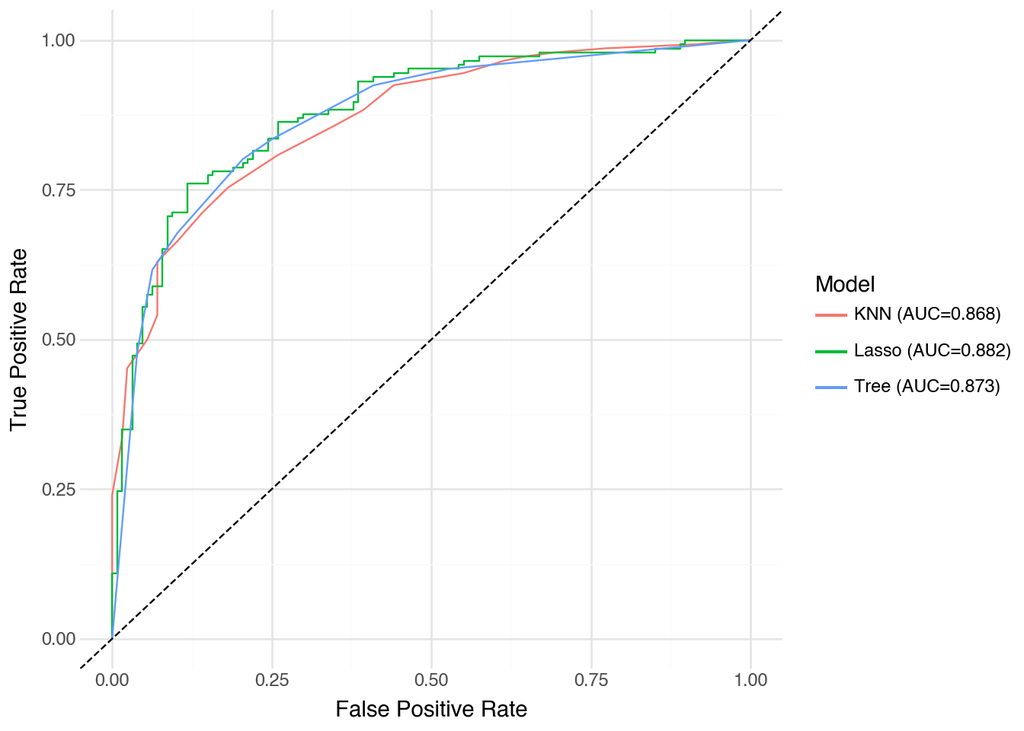

```python
from sklearn.metrics import roc_curve, roc_auc_score
from plotnine import *
import pandas as pd


lasso_probs = lasso_pipeline.predict_proba(X)[:, 1]
lasso_fpr, lasso_tpr, _ = roc_curve(y, lasso_probs)
lasso_auc = roc_auc_score(y, lasso_probs)

knn_probs = knn_pipeline.predict_proba(X)[:, 1]
knn_fpr, knn_tpr, _ = roc_curve(y, knn_probs)
knn_auc = roc_auc_score(y, knn_probs)

# Tree
tree_probs = tree_pipeline.predict_proba(X)[:, 1]
tree_fpr, tree_tpr, _ = roc_curve(y, tree_probs)
tree_auc = roc_auc_score(y, tree_probs)

roc_df = pd.concat([
    pd.DataFrame({"fpr": lasso_fpr, "tpr": lasso_tpr, "Model": f"Lasso (AUC={lasso_auc:.3f})"}),
    pd.DataFrame({"fpr": knn_fpr, "tpr": knn_tpr, "Model": f"KNN (AUC={knn_auc:.3f})"}),
    pd.DataFrame({"fpr": tree_fpr, "tpr": tree_tpr, "Model": f"Tree (AUC={tree_auc:.3f})"})
])

(ggplot(roc_df, aes(x="fpr", y="tpr", color="Model"))
  + geom_line()
  + geom_abline(intercept=0, slope=1, linetype="dashed")
  + labs(
        x="False Positive Rate",
        y="True Positive Rate",
        color="Model"
    )
  + theme_minimal()
)
```

# Part 2

```python
from sklearn.model_selection import cross_val_predict
from sklearn.metrics import precision_score, recall_score, confusion_matrix

y_pred_lasso_cv = cross_val_predict(lasso_pipeline, X, y, cv=5)
y_pred_knn_cv = cross_val_predict(knn_pipeline, X, y, cv=5)
y_pred_tree_cv = cross_val_predict(tree_pipeline, X, y, cv=5)

lasso_precision = precision_score(y, y_pred_lasso_cv)
knn_precision = precision_score(y, y_pred_knn_cv)
tree_precision = precision_score(y, y_pred_tree_cv)

lasso_recall = recall_score(y, y_pred_lasso_cv)
knn_recall = recall_score(y, y_pred_knn_cv)
tree_recall = recall_score(y, y_pred_tree_cv)

def tnr(y_true, y_pred):
    tn, fp, fn, tp = confusion_matrix(y_true, y_pred).ravel()
    return tn / (tn + fp)

lasso_tnr = tnr(y, y_pred_lasso_cv)
knn_tnr = tnr(y, y_pred_knn_cv)
tree_tnr = tnr(y, y_pred_tree_cv)

print(f"Lasso  — Precision: {lasso_precision:.3f}, Recall: {lasso_recall:.3f}, TNR: {lasso_tnr:.3f}")
print(f"KNN    — Precision: {knn_precision:.3f}, Recall: {knn_recall:.3f}, TNR: {knn_tnr:.3f}")
print(f"Tree   — Precision: {tree_precision:.3f}, Recall: {tree_recall:.3f}, TNR: {tree_tnr:.3f}")
```

```
Lasso  — Precision: 0.788, Recall: 0.815, TNR: 0.748
KNN    — Precision: 0.803, Recall: 0.753, TNR: 0.787
Tree   — Precision: 0.799, Recall: 0.760, TNR: 0.780
```

```python
from sklearn.metrics import accuracy_score

lasso_acc = accuracy_score(y, y_preds_lasso)
knn_acc   = accuracy_score(y, y_preds_knn)
tree_acc  = accuracy_score(y, y_preds_tree)

print(f"Lasso Accuracy: {lasso_acc:.3f}")
print(f"KNN Accuracy:   {knn_acc:.3f}")
print(f"Tree Accuracy:  {tree_acc:.3f}")
```

```
Lasso Accuracy: 0.795
KNN Accuracy:   0.784
Tree Accuracy:  0.799
```

# Part 3

## Q1

We need to minimize false negatives meaning we would maximize recall. Our model with the highest recall is lasso so I would reccommend this one. On future observatios I would expect a recall score for lasso to be around 0.815 with some small fluctuation up or down.

## Q2

We need to maximize the predicted posative rate, meaning we would maximize precision. Our model with the highest precision is knn so I would reccommend this one. On future observations I would expect a precision score of around 0.803 with some fluctuation up or down.

## Q3

For this I would look at my roc auc score and the coefficients of the predictors in the model. The model with the best roc auc score was my lasso model so I would reccomend this one. When looking at its coeficients we can see that sex, thalach, and CP, had the highest impact. On future observatinos I would expect the roc auc score to be around 0.86839 with some fluctuation up or down.

## Q4

For this I would look at Accuracy. This is becasue it will tell us how good our model prediction compares to the actual values. The model with the best accuracy is the decision tree so I would reccommend this one. On future observations I would expect the accuracy score around 0.8 with some fluctuation up or down.

# Part 4

```python
ha_validation = pd.read_csv("https://www.dropbox.com/s/jkwqdiyx6o6oad0/heart_attack_validation.csv?dl=1")

X_val = ha_validation.drop(columns=['output'])
y_val = ha_validation['output']
```

```python
y_pred_lasso  = lasso_pipeline.predict(X_val)
y_proba_lasso = lasso_pipeline.predict_proba(X_val)[:, 1]

y_pred_knn  = knn_pipeline.predict(X_val)
y_proba_knn = knn_pipeline.predict_proba(X_val)[:, 1]

y_pred_tree  = tree_pipeline.predict(X_val)
y_proba_tree = tree_pipeline.predict_proba(X_val)[:, 1]
```

```python
from sklearn.metrics import confusion_matrix, roc_auc_score, precision_score, recall_score

def evaluate_model(name, y_true, y_pred, y_proba):
    cm = confusion_matrix(y_true, y_pred)
    roc_auc = roc_auc_score(y_true, y_proba)
    precision = precision_score(y_true, y_pred)
    recall = recall_score(y_true, y_pred)

    print(f"--- {name} ---")
    print("Confusion Matrix:")
    print(cm)
    print(f"ROC AUC: {roc_auc:.3f}")
    print(f"Precision: {precision:.3f}")
    print(f"Recall: {recall:.3f}")
    print()

evaluate_model("Lasso", y_val, y_pred_lasso, y_proba_lasso)
evaluate_model("KNN", y_val, y_pred_knn, y_proba_knn)
evaluate_model("Decision Tree", y_val, y_pred_tree, y_proba_tree)
```

```
--- Lasso ---
Confusion Matrix:
[[ 9  2]
 [ 5 14]]
ROC AUC: 0.890
Precision: 0.875
Recall: 0.737

--- KNN ---
Confusion Matrix:
[[10  1]
 [ 8 11]]
ROC AUC: 0.883
Precision: 0.917
Recall: 0.579

--- Decision Tree ---
Confusion Matrix:
[[ 9  2]
 [ 7 12]]
ROC AUC: 0.833
Precision: 0.857
Recall: 0.632
```

# Part 5

```python
from sklearn.metrics import cohen_kappa_score

kappa_lasso = cohen_kappa_score(y, y_preds_lasso)
kappa_knn   = cohen_kappa_score(y, y_preds_knn)
kappa_tree  = cohen_kappa_score(y, y_preds_tree)

print("Cohen Kappa (Lasso):", kappa_lasso)
print("Cohen Kappa (KNN):  ", kappa_knn)
print("Cohen Kappa (Tree): ", kappa_tree)
```

```
Cohen Kappa (Lasso): 0.5860500379075056
Cohen Kappa (KNN):   0.568535533470842
Cohen Kappa (Tree):  0.5957297864893245
```

From my research, it looks like Cohen Kappa is a measure used to measure the level of agreement between two sets of data. It looks like its interpreted as the level of chance that the two data sets are randomly correlated. So a score of 1 means no chance that its randomly correlated, and a score of 0 means all the correlation is up to chance. One situation it would be useful to use Cohens Kapps is when comparing model predicted value to true human diagnosed value. This is because we are comparing the agreement between the two and we are factoring in the chance that there is random correlation. This could relate to Q4 in part 3. If we were to use Cohens Kappa as the metric we could actuallt still choose the same model (tree) so it wouldnt impact what model we chose in this case.